# Project 2: Data Mining, Classification, Prediction

SDS322E

# Mining, Classification, Prediction

## Abbey Flynn

### Introduction

```r
library(tidyverse)
cleandatajoin <- read_csv("~/project2/projectdata.csv")
```

I chose to continue to work with my joined data from Project 1 because this additional analysis may allow me to better analyze how these two datasets are related. As a reminder, the first data set was differential gene expression analysis results obtained from comparing the RNAseq data of two different cell populations using DESeq. It contained variables for gene names, mean expression signal across all samples, log2 fold change, adjusted p-value, and a numeric vector specifying whether the gene is expressed or not. The second dataset was one that contains the genome-wide gene expression values from 3 multiple myeloma cancer cell line samples. The variables in this dataset include gene names and 3 sample log2 transformed normalized expression count values.

In this Project, I want to further analyze the possibility that these cells could be cancerous myeloma cells. I can hypothesize that those with higher correlation values will likely become a multiple myeloma cell or may already be one. As mentioned in the previous project, this information could be helpful in that it can help take preventative measures to catch myeloma cancer cells early if a cell is found to express this gene.

### Cluster Analysis

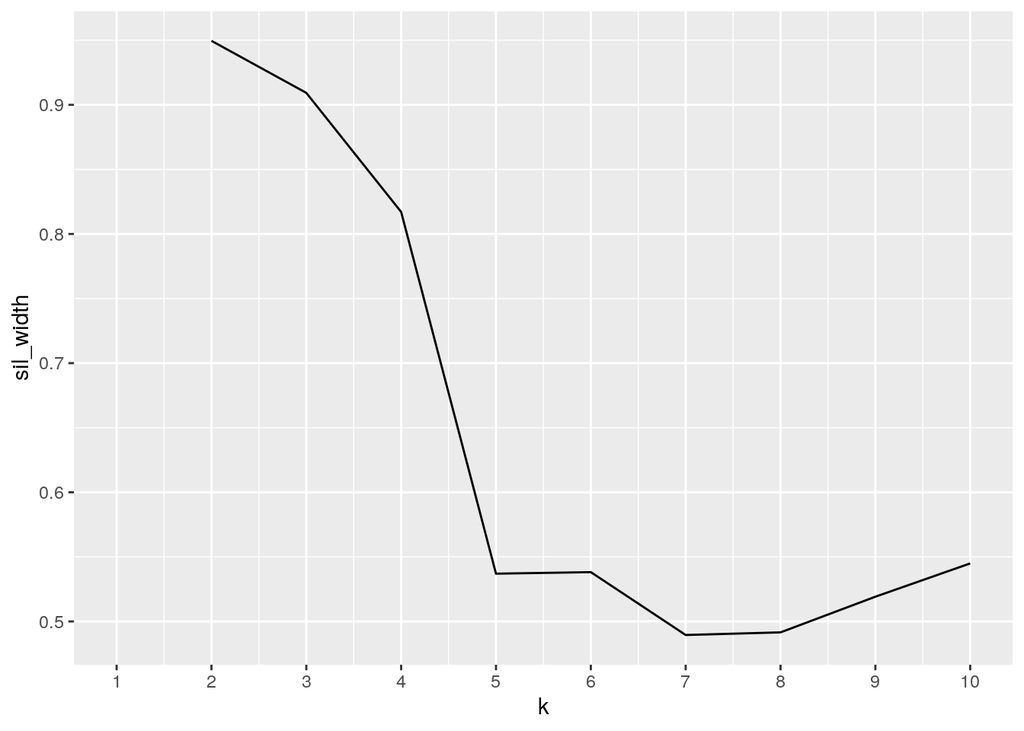

```r
library(cluster)

clust_dat <- cleandatajoin %>% dplyr::select(sample1, sample2,
    sample3, baseMean)
sil_width <- vector()  #empty vector to hold mean sil width
for (i in 2:10) {
    kms <- kmeans(clust_dat, centers = i)  #compute k-means solution
    sil <- silhouette(kms$cluster, dist(clust_dat))  #get sil widths
    sil_width[i] <- mean(sil[, 3])  #take averages (higher is better)
}
ggplot() + geom_line(aes(x = 1:10, y = sil_width)) + scale_x_continuous(name = "k",
    breaks = 1:10)
```

```r
pam1 <- clust_dat %>% pam(k = 2)
pam1
```

```
## Medoids:
##       ID sample1 sample2 sample3    baseMean
## [1,] 246     106      64      55    9.615708
## [2,] 271     107      55      56 1065.306074
## Clustering vector:
##   [1] 1 1 1 1 1 1 1 1 2 1 1 2 1 1 1 1 1 1 1 1 1 1 1 1 1 1 1 1 1 1 1 1 1 1 1 1 1
##  [38] 1 1 1 1 1 1 1 2 1 1 1 1 1 1 1 1 1 1 2 1 1 1 1 2 1 1 1 1 1 1 1 1 1 1 1 1 1
##  [75] 1 1 1 1 1 1 1 1 1 1 1 1 1 2 1 2 2 1 1 1 1 1 1 1 1 1
##  [ reached getOption("max.print") -- omitted 767 entries ]
## Objective function:
##    build     swap
## 181.3313 181.2645
##
## Available components:
##  [1] "medoids"    "id.med"     "clustering" "objective"  "isolation"
##  [6] "clusinfo"   "silinfo"    "diss"       "call"       "data"
```

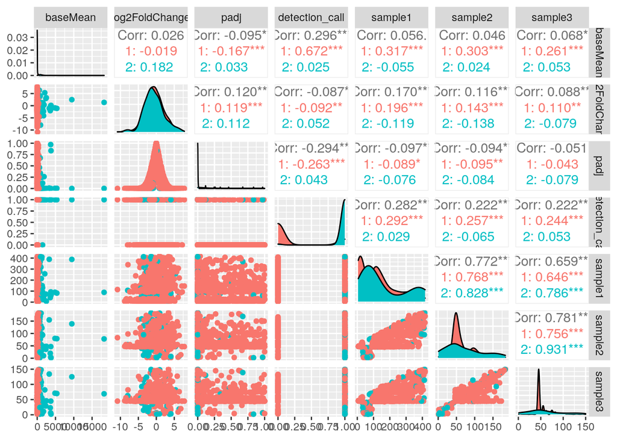

```r
library(GGally)
ggpairs(cleandatajoin, columns = 2:8, aes(color = as.factor(pam1$clustering)))
```

First, in order to find which clustering amount would be a good fit I ran the silhouette width function. This allowed me to find that the goodness of fit, best k, is equal to 2 because this is where the graph had the highest silhouette width. I then used pam clustering and ggpairs to be able to graph the relationships between all of the variables. I found that the clusters in detection_call are extremely distinct almost on the opposite spectrum of each other. For Log2FoldChange, the clusters are almost exactly the same. It is interesting to me that sample2 and sample3 both have high peaks for cluster one but then are more flat for cluster2. Overall, I found that most of the correlations are positive.

### Dimensionality Reduction with PCA

```r
cleandatajoin_pca <- cleandatajoin %>% select(-name) %>% scale %>%
    princomp
summary(cleandatajoin_pca, loadings = T)
```

```
## Importance of components:
##                           Comp.1    Comp.2    Comp.3    Comp.4    Comp.5
## Standard deviation     1.6278071 1.1829010 1.0072075 0.9061901 0.7751301
## Proportion of Variance 0.3789737 0.2001244 0.1450912 0.1174470 0.0859315
## Cumulative Proportion  0.3789737 0.5790981 0.7241893 0.8416362 0.9275677
##                            Comp.6    Comp.7
## Standard deviation     0.57132078 0.4243038
## Proportion of Variance 0.04668348 0.0257488
## Cumulative Proportion  0.97425120 1.0000000
##
## Loadings:
##                Comp.1 Comp.2 Comp.3 Comp.4 Comp.5 Comp.6 Comp.7
## baseMean        0.114  0.448  0.667  0.360  0.456
## log2FoldChange  0.101 -0.381  0.669 -0.602 -0.136 -0.121
## padj           -0.128 -0.538  0.265  0.692 -0.378
## detection_call  0.276  0.550  0.110        -0.769 -0.113
## sample1         0.541 -0.126                       0.718 -0.415
## sample2         0.558 -0.156 -0.117         0.132         0.794
## sample3         0.530 -0.147 -0.102  0.155  0.139 -0.671 -0.439
```

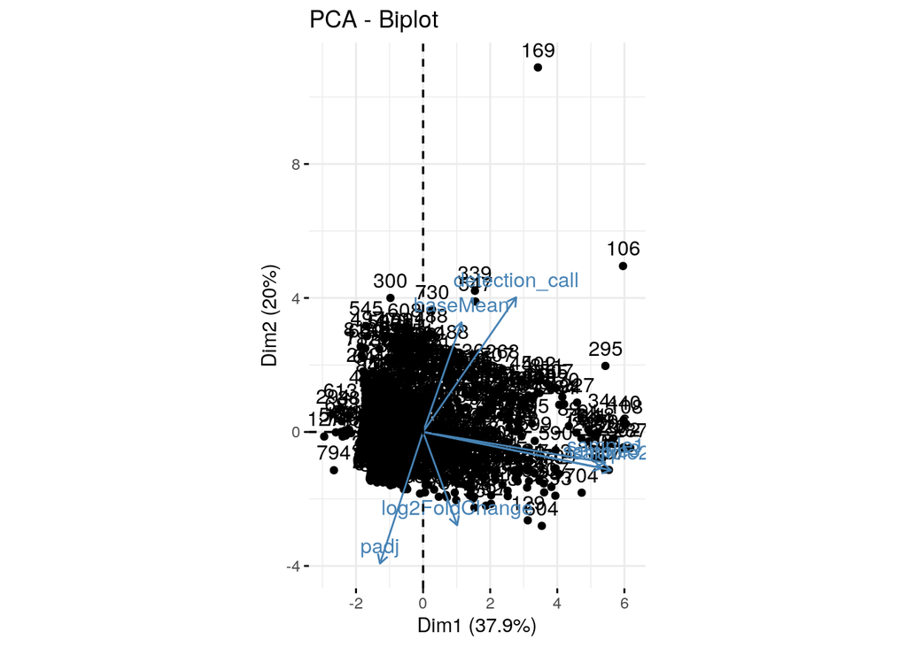

```r
library(factoextra)
fviz_pca_biplot(cleandatajoin_pca, ) + coord_fixed() + theme(legend.position = "none")
```

High PCs mean high variance and low PCs mean low variance. For PC1, the proportion of variance is 0.38 and for PC2, the proportion of variance is 0.2. This makes sense because usually PC1 captures the most variation among the data set. In PC1, baseMean, log2FoldChange, detection_call, sample1, sample2, and sample3 all contribute positively where as padj contributes negatively. On the other hand, in PC2, log2FoldChange, padj, sample1, sample2, and sample3 all contribute negatively and baseMean and detection_call contribute positively. The biplot is very interesting and seemingly cluttered because there are 867 genes to be looking at. However, you can definitely see the general relation that each column has to the data.

### Linear Classifier

```r
# linear classifier code here
logistic_fit <- glm(detection_call ~ baseMean + sample1 + sample2 +
    sample3, data = cleandatajoin, family = "binomial")
prob_reg <- predict(logistic_fit, type = "response")
prob_reg
```

[output not shown]

```r
class_diag(prob_reg, cleandatajoin$detection_call, positive = 1)
```

```
##            acc   sens   spec    ppv     f1     ba    auc
## Metrics 0.9135 0.7009 0.9876 0.9515 0.8072 0.8442 0.9732
```

```r
# confusion matrix
y <- cleandatajoin$detection_call
y <- factor(y, levels = c(1, 0))
y_hat <- prob_reg > 0.5
y
```

```
##   [1] 1 0 0 0 0 0 0 1 1 0 1 1 0 0 0 0 0 1 0 1 0 0 1 1 0 0 1 0 0 0 1 0 0 1 0 0 0
##  [38] 0 0 0 1 1 1 0 1 1 0 0 0 0 0 0 1 0 0 1 0 0 1 0 1 0 0 0 1 1 0 0 1 1 0 0 1 1
##  [75] 0 1 0 0 0 0 0 0 0 1 0 0 1 1 1 1 1 0 0 0 0 0 0 0 0 1
##  [ reached getOption("max.print") -- omitted 767 entries ]
## Levels: 1 0
```

```r
y_hat
```

[output not shown]

```r
y_hat <- factor(y_hat, levels = c(T, F))
table(actual = y, predicted = y_hat)
```

```
##       predicted
## actual TRUE FALSE
##      1  157    67
##      0    8   635
```

```r
# CV
set.seed(322)
k = 10
data <- sample_frac(cleandatajoin)  #randomly order rows
folds <- rep(1:k, length.out = nrow(cleandatajoin))  #create folds
diags <- NULL
i = 1
for (i in 1:k) {

    # create training and test sets
    train <- data[folds != i, ]
    test <- data[folds == i, ]
    truth <- test$detection_call
    # train model
    fit <- glm(detection_call ~ baseMean + sample1 + sample2 +
        sample3, data = train, family = "binomial")
    # test model
    probs <- predict(fit, newdata = test, type = "response")
    # get performance metrics for each fold
    diags <- rbind(diags, class_diag(probs, truth, positive = 1))
}
# average performance metrics across all folds
summarize_all(diags, mean)
```

```
##       acc    sens   spec     ppv      f1      ba     auc
## 1 0.90654 0.67981 0.9861 0.94836 0.78645 0.83295 0.97294
```

Based on the probability model, we were able to find which genes have the largest chance of having detection call 1 which means that it is most likely expressed in myeloma cells. This prob_reg variable is helpful to know because this may help determine which genes to look for when observing whether a cell will become a myeloma cell. In terms of AUC, this data is great! The higher the AUC, the better the performance of the model at distinguishing between the positive and negative classes. Therefore, this model does a great job of doing so. There also does not seem to be overfitting here because both the test and cross validation values have an AUC of 0.973.

### Non-Parametric Classifier

```r
# non-parametric classifier code here
library(caret)
knn_fit <- knn3(detection_call ~ baseMean + sample1 + sample2 +
    sample3, data = cleandatajoin)
prob_knn <- predict(knn_fit, cleandatajoin)
prob_knn
```

```
##          0   1
##   [1,] 0.0 1.0
##   [2,] 1.0 0.0
##   [3,] 1.0 0.0
##   [4,] 1.0 0.0
##   [5,] 1.0 0.0
##   [6,] 1.0 0.0
##   [7,] 1.0 0.0
##   [8,] 0.8 0.2
##   [9,] 0.0 1.0
##  [10,] 1.0 0.0
##  [11,] 0.2 0.8
##  [12,] 0.0 1.0
##  [13,] 1.0 0.0
##  [14,] 1.0 0.0
```

[output cut: 37 more lines]

```r
class_diag(prob_knn[, 2], cleandatajoin$detection_call, positive = 1)
```

```
##            acc   sens   spec   ppv     f1     ba    auc
## Metrics 0.9366 0.8884 0.9533 0.869 0.8786 0.9209 0.9874
```

```r
# confusion matrix part
table(truth = factor(cleandatajoin$detection_call == 1, levels = c("TRUE",
    "FALSE")), prediction = factor(prob_knn[, 2] > 0.5, levels = c("TRUE",
    "FALSE")))
```

```
##        prediction
## truth   TRUE FALSE
##   TRUE   199    25
##   FALSE   30   613
```

```r
# train the model ##having issues with the cross validation
# part your code here
set.seed(1234)
k = 10  #choose number of folds
data1 <- cleandatajoin[sample(nrow(cleandatajoin)), ]  #randomly order rows
folds1 <- cut(seq(1:nrow(cleandatajoin)), breaks = k, labels = F)  #create folds
diags1 <- NULL
for (i in 1:k) {
    ## Create training and test sets
    train1 <- data[folds1 != i, ]
    test1 <- data[folds1 == i, ]
    truth1 <- test1$detection_call  ## Truth labels for fold i
    ## Train model on training set (all but fold i)
    fit1 <- knn3(detection_call ~ baseMean + sample1 + sample2 +
        sample3, data = cleandatajoin)
    ## Test model on test set (fold i)
    probs1 <- predict(fit, newdata = test, type = "response")
    ## Get diagnostics for fold i
    diags1 <- rbind(diags1, class_diag(probs, truth, positive = 1))
}
summarize_all(diags1, mean)
```

```
##     acc  sens spec ppv     f1     ba    auc
## 1 0.907 0.619    1   1 0.7647 0.8095 0.9795
```

### Regression/Numeric Prediction

```r
# regression model code here
fit2 <- lm(detection_call ~ baseMean + sample1 + sample2 + sample3,
    data = cleandatajoin)
yhat1 <- predict(fit2)


## MSE for the overall data set
mean((cleandatajoin$detection_call - yhat1)^2)  #mean squared error (MSE)
```

```
## [1] 0.1610564
```

```r
# cross-validation

set.seed(1234)
k = 5  #choose number of folds
data2 <- cleandatajoin[sample(nrow(cleandatajoin)), ]  #randomly order rows
folds2 <- cut(seq(1:nrow(cleandatajoin)), breaks = k, labels = F)  #create folds
diags2 <- NULL
for (i in 1:k) {
    train2 <- data[folds2 != i, ]
    test2 <- data[folds2 == i, ]
    ## Fit linear regression model to training set
    fit2 <- lm(detection_call ~ baseMean + sample1 + sample2 +
        sample3, data = train)
    ## Get predictions/y-hats on test set (fold i)
    yhat2 <- predict(fit2, newdata = test)
    ## Compute prediction error (MSE) for fold i
    diags2 <- mean((test$detection_call - yhat1)^2)
}
mean(diags2)  ## get average MSE across all folds (much higher error)!
```

```
## [1] 0.2126888
```

### Python

```r
library(reticulate)
use_python("/usr/bin/python3", required = F)
geneName <- "The particular genes that we will find in this data set"
```

```python
# python code here
expression="are said to be expressed based on the detection_call being 1 or 0."
print(r.geneName,expression)
```

```
## The particular genes that we will find in this data set are said to be expressed based on the detection_call being 1 or 0.
```

```r
cat(c(geneName, py$expression))
```

```
## The particular genes that we will find in this data set are said to be expressed based on the detection_call being 1 or 0.
```

I saved the first half of a sentence in an R studio variable. Then, I saved the other half of the sentence into the python code chunk. Using the r.geneName accesses the R defined object with r. The py$expression accesses the Python-defined object. Then, using the print and cat functions I was able to combine both of these different languages to form a sentence in both R and python.